# Práctica 2: Booking Data Cleaning

Donde rechazaremos la hipótesis nula cuando el pvalor del test sea inferior a un nivel de significación igual a 0.05.

```r
# Ajustamos el test de fligner-killeen para page_count y air_conditioning
fligner.test(page_count ~ air_conditioning, data = booking)
```

```
##
##  Fligner-Killeen test of homogeneity of variances
##
## data:  page_count by air_conditioning
## Fligner-Killeen:med chi-squared = 0.20066, df = 1, p-value = 0.6542
```

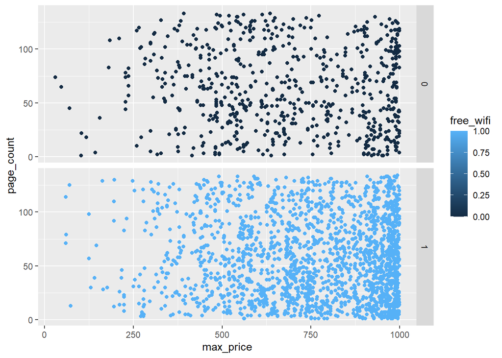

```r
# Generamos el scatter para compromar la homocedasticidad de page_count cuando dividimos por free_wifi.
ggplot(booking, aes(x = max_price, y = page_count, color = free_wifi)) +
  geom_point()+
  facet_grid(free_wifi~.)
```

```r
# Ajustamos el test de fligner-killeen para page_count y free_wifi
fligner.test(page_count ~ free_wifi, data = booking)
```

```
##
##  Fligner-Killeen test of homogeneity of variances
##
## data:  page_count by free_wifi
## Fligner-Killeen:med chi-squared = 0.40063, df = 1, p-value = 0.5268
```

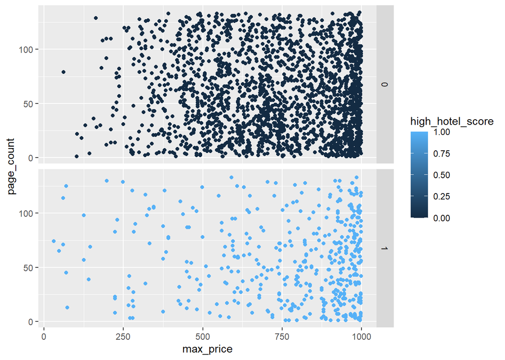

```r
# Generamos la variable para el contraste que realizaremos en la siguiente sección. Si el hotel score es mayor a 9 se marca con una flag
booking <- booking %>%
  mutate(high_hotel_score = ifelse(hotel_score >= 9, 1, 0))

# Ploteamos el scatter para comprobar la homocedasticidad de page_count cuando dividimos por la nueva variable.
ggplot(booking, aes(x = max_price, y = page_count, color = high_hotel_score)) +
  geom_point()+
  facet_grid(high_hotel_score~.)
```

```r
# Ajustamos el test de fligner-killeen para page_count y la nueva variable
fligner.test(page_count ~ high_hotel_score, data = booking)
```

```
##
##  Fligner-Killeen test of homogeneity of variances
##
## data:  page_count by high_hotel_score
## Fligner-Killeen:med chi-squared = 2.8946, df = 1, p-value = 0.08888
```

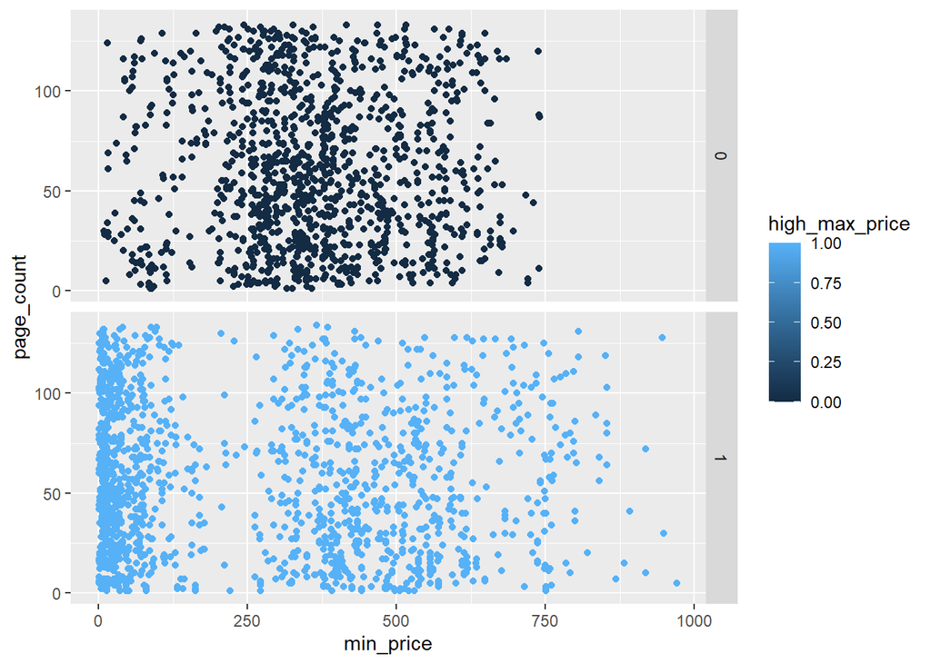

```r
# Generamos la variable para el contraste que realizaremos en la siguiente sección. Si el precio máximo supera la media de precios maximos
# pone un flags
booking <- booking %>%
  mutate(high_max_price = ifelse(max_price >= mean(max_price), 1, 0))

# Ploteamos el scatter para comprobar la homocedasticidad de page_count cuando dividimos por la nueva variable.
ggplot(booking, aes(x = min_price, y = page_count, color = high_max_price)) +
  geom_point()+
  facet_grid(high_max_price~.)
```

```r
# Ajustamos el test de fligner-killeen para page_count y la nueva variable
fligner.test(page_count ~ high_max_price, data = booking)
```

```
##
##  Fligner-Killeen test of homogeneity of variances
##
## data:  page_count by high_max_price
## Fligner-Killeen:med chi-squared = 0.22846, df = 1, p-value = 0.6327
```

Tras realizar tests a un gran número de variables de interés (principalmente las que van a ser sujeto de estudio para los tests estadísticos, es decir, air_conditioning, free_wifi y dos variables nuevas que hemos creado, high_hotel_score y high_max_price), se ha determinado que existe homogeneidad de varianzas, por lo que no nos encontraremos con problemas de heterogeneidad a la hora de realizar pruebas de hipótesis.

#### 4.3 Aplicación de pruebas estadísticas para comparar los grupos de datos

En este apartado se aplicarán distintas pruebas estadísticas para comparar los distintos grupos de datos de los que disponemos y ver cual es su relación con la variable objetivo page_count. Esto nos permitirá evaluar que variables tienen un impacto significativo sobre la variable objetivo y cuales no. A continuación, se recogen unas pocas hipótesis, aunque sería posible evaluar otras que también pareciesen interesantes, dado el carácter académico de este trabajo nos centraremos exclusivamente en estudiar la influencia de las variables:

- **air_conditioning**
- **has_free_cancelation**
- **hotel_score**
- **max_price**

Las hipótesis que trataremos de verificar serán las siguientes:

- Aquellos hoteles con aire acondicionado tendrán una mejor posición (page_count inferior) a los que no dispongan de este.
- Los hoteles con cancelación gratuita tendrán una posición diferente a los que no dispongan de esta.
- Los hoteles con una puntuación global superior a un 9 tendrán un mejor posicionamiento.
- Los hoteles con un precio máximo superior a la media tendrán un peor posicionamiento.

A continuación se estudiará cada una de estas hipótesis y el resultado obtenido.

**Hipótesis 1** La primera hipótesis evalúa la influencia de que un hotel disponga de aire acondicionado en el posicionamiento del hotel, suponiendo que un hotel con aire acondicionado tendrá un posicionamiento mejor, es decir menor **page_count** que un hotel que no disponga de aire acondicionado. A continuación se plantea la hipótesis nula ($H_{0}$) y la alternativa ($H_{1}$).

- $H_{0}:$ La posición global de un hotel con aire acondicionado y uno sin serán iguales.
- $H_{1}:$ La posición global de un hotel con aire acondicionado será mejor (inferior) a la de uno sin.

O en otras palabras:

- $H_{0}: \mu_0 = \mu_1$
- $H_{1}: \mu_0 \le \mu_1$

En este caso se trata de un **contraste de hipótesis de dos muestras independientes sobre la media con varianzas no conocidas**. Aunque previamente no se ha cumplido la normalidad de los datos por el Teorema del Límite Central podemos considerar la normalidad de los datos y aplicar un test paramétrico. En este caso aplicaremos un **test unilateral por la izquierda**, suponiendo (por lo que se ha visto en el apartado anterior) que las varianzas son iguales, por lo que el estadístico de contraste será:

$$T = \frac{\overline{X_1} -
\overline{X_2}}{\sqrt{(\frac{1}{n_1}+\frac{1}{n_2})}·\frac{(n_1-1)·S^2_1+(n_2-1)·S^2_2}{n_1+n_2-2}}
\textrm{~} t_{n_1 + n_2 - 2}$$

```r
# Buscamos el conjunto de datos de estudio:
X1 <- booking %>%
  filter(air_conditioning==1) %>%
  dplyr::select("page_count")
X1 <- as.vector(unlist(X1),'numeric')

X2 <- booking %>%
  filter(air_conditioning==0) %>%
  dplyr::select("page_count")
X2 <- as.vector(unlist(X2),'numeric')

# Buscamos la varianza de ambas variables
var1 <- var(X1)
var2 <- var(X2)

# Definimos el nivel de confianza al 95%
alfa <- 0.05

# Buscamos las medias y la el número de registros en cada variable
mean1 <- mean(X1); n1 <- length(X1)
mean2 <- mean(X2); n2 <- length(X2)

# Calculamos el valor observado y el valor crítico
tobs <- (mean1-mean2)/sqrt((1/n1 + 1/n2) * ((n1-1)*var1 + (n2-1)*var2)/(n1+n2-2))
tcrit <- pt(1-alfa, df = (n1+n2-2))

# Finalmente calculamos el pvalue
pvalue <- pt(tobs, lower.tail=TRUE, df = (n1+n2-2))
print(paste("The p-value obtained is: ", pvalue))
```

```
## [1] "The p-value obtained is:  5.33600165433049e-13"
```

```r
# Mostramos las medias de las dos variables
print(paste("The mean of the group 1 is: ", mean(X1)))
```

```
## [1] "The mean of the group 1 is:  55.4309293146753"
```

```r
print(paste("The mean of the group 2 is: ", mean(X2)))
```

```
## [1] "The mean of the group 2 is:  64.871609403255"
```

Se obtiene un p-value muy cercano a 0, y muy inferior a 0.05, por lo que podemos rechazar la hipótesis nula y considerar que **la presencia de aire acondicionado en un hotel mejorará el posicionamiento de este en el buscador de Booking**. Esto se observa también al obtener una media de posicionamiento inferior en más de 9 posiciones en aquellos hoteles con aire acondicionado.

**Hipótesis 2** Esta segunda hipótesis trata de evaluar la influencia de la cancelación gratuita, la cual para aportar una mayor diversidad en los análisis realizados, puede estar asociada a una posición distinta (inferior o superior) que la de un hotel sin cancelación gratuita. Definimos esta hipótesis mediante las hipótesis nula ($H_{0}$) y alternativa ($H_{1}$) siguientes:

- $H_{0}:$ La posición global de un hotel con cancelación gratuita y uno sin serán iguales.
- $H_{1}:$ La posición global de un hotel con cancelación gratuita será distinta a la de uno sin.

O en otras palabras:

- $H_{0}: \mu_0 = \mu_1$
- $H_{1}: \mu_0 \neq \mu_1$

En este caso se trata de un **contraste de hipótesis de dos muestras independientes sobre la media con varianzas no conocidas**, al igual que en el caso anterior por el TLC podemos aceptar la normalidad de los datos y aplicar un test paramétrico, en concreto un **test bilateral**.

```r
# Buscamos el conjunto de datos de estudio:
X1 <- booking %>%
  filter(has_free_cancelation==1) %>%
  dplyr::select("page_count")
X1 <- as.vector(unlist(X1),'numeric')

X2 <- booking %>%
  filter(has_free_cancelation==0) %>%
  dplyr::select("page_count")
X2 <- as.vector(unlist(X2),'numeric')

# Buscamos la varianza de ambas variables
var1 <- var(X1)
var2 <- var(X2)

# Definimos el nivel de confianza al 95%
alfa <- 0.05

# Buscamos las medias y la el número de registros en cada variable
mean1 <- mean(X1); n1 <- length(X1)
mean2 <- mean(X2); n2 <- length(X2)

# Calculamos el valor observado y el valor crítico
tobs <- (mean1-mean2)/sqrt((1/n1 + 1/n2) * ((n1-1)*var1 + (n2-1)*var2)/(n1+n2-2))
tcrit <- pt(1-alfa/2, df = (n1+n2-2))

# Finalmente calculamos el pvalue
pvalue <- pt(tobs, lower.tail=TRUE, df = (n1+n2-2))
print(paste("The p-value obtained is: ", pvalue))
```

```
## [1] "The p-value obtained is:  0.000376181455513205"
```

```r
# Mostramos las medias de las dos variables
print(paste("The mean of the group 1 is: ", mean(X1)))
```

```
## [1] "The mean of the group 1 is:  57.6696284329564"
```

```r
print(paste("The mean of the group 2 is: ", mean(X2)))
```

```
## [1] "The mean of the group 2 is:  67.3128491620112"
```

Observamos que se obtiene un p-value inferior a 0.05 por lo que debemos rechazar la hipótesis nula y, por lo tanto, obtenemos que **un hotel con cancelación gratuita obtendrá un posicionamiento distinto al de un hotel sin cancelación gratuita**. En concreto se ha observado que los hoteles con cancelación gratuita obtienen un mejor posicionamiento que aquellos sin.

**Hipótesis 3** A continuación evaluamos la influencia de la puntuación global del hotel. En este caso evaluaremos si un hotel con una puntuación global (**hotel_score**) superior o igual a un 9.0 obtiene un mejor posicionamiento que un hotel con una peor puntuación. A continuación se plantea la hipótesis nula ($H_{0}$) y la alternativa ($H_{1}$)

Los hoteles con una puntuación global superior a un 9 tendrán un mejor posicionamiento.

- $H_{0}:$ La posición global de un hotel con una puntuación global mayor o igual a 9.0 y uno con una puntuación inferior serán iguales.
- $H_{1}:$ La posición global de un hotel con una puntuación global mayor o igual a 9.0 será mejor (menor) que uno con una puntuación inferior.

O en otras palabras:

- $H_{0}: \mu_0 = \mu_1$
- $H_{1}: \mu_0 \le \mu_1$

En este caso se trata de un **contraste de hipótesis de dos muestras independientes sobre la media con varianzas no conocidas**. Al igual que en los casos anteriores podemos asumir la normalidad de los datos por el TLC. En este caso se aplicará un **test unilateral por la izquierda**.

```r
# Buscamos el conjunto de datos de estudio:
X1 <- booking %>%
  filter(high_hotel_score == 1) %>%
  dplyr::select("page_count")
X1 <- as.vector(unlist(X1),'numeric')

X2 <- booking %>%
  filter(high_hotel_score == 0) %>%
  dplyr::select("page_count")
X2 <- as.vector(unlist(X2),'numeric')

# Buscamos la varianza de ambas variables
var1 <- var(X1)
var2 <- var(X2)

# Definimos el nivel de confianza al 95%
alfa <- 0.05

# Buscamos las medias y la el número de registros en cada variable
mean1 <- mean(X1); n1 <- length(X1)
mean2 <- mean(X2); n2 <- length(X2)

# Calculamos el valor observado y el valor crítico
tobs <- (mean1-mean2)/sqrt((1/n1 + 1/n2) * ((n1-1)*var1 + (n2-1)*var2)/(n1+n2-2))
tcrit <- pt(1-alfa, df = (n1+n2-2))

# Finalmente calculamos el pvalue
pvalue <- pt(tobs, lower.tail=TRUE, df = (n1+n2-2))
print(paste("The p-value obtained is: ", pvalue))
```

```
## [1] "The p-value obtained is:  0.0483871639663221"
```

```r
# Mostramos las medias de las dos variables
print(paste("The mean of the group 1 is: ", mean(X1)))
```

```
## [1] "The mean of the group 1 is:  55.9346210995542"
```

```r
print(paste("The mean of the group 2 is: ", mean(X2)))
```

```
## [1] "The mean of the group 2 is:  58.5683229813665"
```

Se obtiene un valor del p-value de 0.048, el cual aún siendo muy cercano a 0.05 que utilizamos para el intérvalo de confianza es inferior, por lo que se debe rechazar la hipótesis nula y podemos decir que **un hotel con una puntuación superior a 9.0 obtendrá un mejor posicionamiento que el resto de hoteles**. No obstante, por el valor obtenido podemos determinar que esta variable no es tan influyente como el aire acondicionado o la cancelación gratuita.

**Hipótesis 4** Finalmente evaluamos la influencia del precio máximo del hotel considerando que un hotel con un mayor precio máximo tendrá un peor posicionamiento. Para ello consideraremos las siguientes hipótesis nula ($H_{0}$) y alternativa ($H_{1}$)

Los hoteles con un precio máximo superior a la media tendrán un peor posicionamiento.

- $H_{0}:$ La posición global de un hotel con precio máximo superior a la media y uno inferior serán iguales.
- $H_{1}:$ La posición global de un hotel con precio máximo superior a la media será peor (superior) a la de uno con precio inferior

O en otras palabras:

- $H_{0}: \mu_0 = \mu_1$
- $H_{1}: \mu_0 \le \mu_1$

En este caso también realizaremos un **contraste de hipótesis de dos muestras independientes sobre la media con varianzas no conocidas**. Como se ha visto en los casos anteriores, por el TLC podemos asumir la normalidad de los datos y aplicaremos un test paramétrico, en este caso emplearemos un **test unilateral por la derecha**.

```r
# Buscamos el conjunto de datos de estudio:
X1 <- booking %>%
  filter(high_max_price == 1) %>%
  dplyr::select("page_count")
X1 <- as.vector(unlist(X1),'numeric')

X2 <- booking %>%
  filter(high_max_price == 0) %>%
  dplyr::select("page_count")
X2 <- as.vector(unlist(X2),'numeric')

# Buscamos la varianza de ambas variables
var1 <- var(X1)
var2 <- var(X2)

# Definimos el nivel de confianza al 95%
alfa <- 0.05

# Buscamos las medias y la el número de registros en cada variable
mean1 <- mean(X1); n1 <- length(X1)
mean2 <- mean(X2); n2 <- length(X2)

# Calculamos el valor observado y el valor crítico
tobs <- (mean1-mean2)/sqrt((1/n1 + 1/n2) * ((n1-1)*var1 + (n2-1)*var2)/(n1+n2-2))
tcrit <- pt(1-alfa, df = (n1+n2-2))

# Finalmente calculamos el pvalue
pvalue <- pt(tobs, lower.tail=FALSE, df = (n1+n2-2))
print(paste("The p-value obtained is: ", pvalue))
```

```
## [1] "The p-value obtained is:  0.979867959556137"
```

```r
# Mostramos las medias de las dos variables
print(paste("The mean of the group 1 is: ", mean(X1)))
```

```
## [1] "The mean of the group 1 is:  56.9824644549763"
```

```r
print(paste("The mean of the group 2 is: ", mean(X2)))
```

```
## [1] "The mean of the group 2 is:  59.4509254066181"
```

En este caso se ha obtenido un p-value de 0.98, por lo que se acepta la hipótesis nula y obtenemos que **los hoteles con un precio máximo superior a la media no obtiene un peor posicionamiento que el resto de hoteles**. Es más en este caso se ha observado que que la media de posicionamiento de los hoteles con un precio máximo superior a la media ha sido ligeramente mejor al resto.

#### 4.4 Aplicación de funciones lineales para resolución del problema

Una vez analizados los distintos contrastes de hipótesis y hayada la correlación entre las distintas variables, tenemos un conocimiento del conjunto de datos lo suficientemente extenso como para analizar mediante una función lineal el posicionamiento de un hotel en el buscador de Booking.

Tras los resultados que se han obtenido observamos que hay distintas variables que pueden tener una mayor influencia sobre nuestra variable objetivo. Por un lado, si nos basamos en lo obtenido tras el análisis de correlación hayamos que variables como **min_price**, **comfort_score**, **cleanliness_score**, **safe** o **hotel_score** entre otros tienen una gran relevancia. Por otro lado, variables como **air_conditioning** o **has_free_cancelation** han mostrado una relevancia significativa durante el contraste de hipótesis.

En este apartado comenzaremos tratando de ajustar una regresión lineal simple aproximando la variable dependiente **page_count** con la variable explicativa que ha proporcionado una mayor correlación, que ha resultado ser **comfort_score**.

```r
#Create the linear model
mrl <- lm(page_count~comfort_score, data=booking)

#Evaluate the data
summary(mrl)
```

```
##
## Call:
## lm(formula = page_count ~ comfort_score, data = booking)
##
## Residuals:
##     Min      1Q  Median      3Q     Max
## -59.376 -32.415  -4.118  30.495  79.714
##
## Coefficients:
##               Estimate Std. Error t value Pr(>|t|)
## (Intercept)     95.014      8.523  11.149  < 2e-16 ***
## comfort_score   -4.258      0.981  -4.341 1.46e-05 ***
## ---
## Signif. codes:  0 '***' 0.001 '**' 0.01 '*' 0.05 '.' 0.1 ' ' 1
##
## Residual standard error: 37.33 on 3891 degrees of freedom
## Multiple R-squared:  0.004819,   Adjusted R-squared:  0.004563
## F-statistic: 18.84 on 1 and 3891 DF,  p-value: 1.458e-05
```

Obtenemos un valor de R-squared de 0.005, lo que es un valor muy bajo y representa una aproximación muy mala de la variable dependiente.

Con el objetivo de mejorar los resultados obtenidos se realizará una regresión lineal múltiple que considere todas las puntuaciones del hotel para predecir la posición de este. Para ello empleamos las variables: **hotel_score**, **staff_score**, **facilities_score**, **cleanliness_score**, **comfort_score**, **value_for_money_score**, **location_score** y **free_wifi_score**, para ver como la opinión de los clientes afecta en el posicionamiento de este en Booking.

```r
#Create the linear model
mrl_scores <- lm(page_count~hotel_score + staff_score + facilities_score + cleanliness_score + comfort_score + value_for_money_score + location_score + free_wifi_score, data=booking)

#Evaluate the data
summary(mrl_scores)
```

```
##
## Call:
## lm(formula = page_count ~ hotel_score + staff_score + facilities_score +
##     cleanliness_score + comfort_score + value_for_money_score +
##     location_score + free_wifi_score, data = booking)
##
## Residuals:
##     Min      1Q  Median      3Q     Max
## -66.867 -32.255  -4.229  30.134  84.064
##
## Coefficients:
##                       Estimate Std. Error t value Pr(>|t|)
## (Intercept)            98.8740    11.8693   8.330  < 2e-16 ***
## hotel_score            -5.7102     4.4733  -1.277 0.201851
## staff_score             8.8844     1.5676   5.668 1.55e-08 ***
## facilities_score        3.0648     3.2611   0.940 0.347381
## cleanliness_score       0.2208     2.7792   0.079 0.936684
## comfort_score          -2.4574     3.2486  -0.756 0.449424
## value_for_money_score  -8.5827     2.2135  -3.877 0.000107 ***
## location_score         -3.2152     1.2112  -2.655 0.007975 **
## free_wifi_score         2.7024     0.7750   3.487 0.000494 ***
## ---
## Signif. codes:  0 '***' 0.001 '**' 0.01 '*' 0.05 '.' 0.1 ' ' 1
##
## Residual standard error: 37.05 on 3884 degrees of freedom
## Multiple R-squared:  0.02143,    Adjusted R-squared:  0.01942
## F-statistic: 10.63 on 8 and 3884 DF,  p-value: 6.894e-15
```

Se observa que con la regresión lineal multiple R-squared aumenta hasta 0.019, algo mejor que empleando solo una variable, pero aún así los resultados obtenidos son muy malos y no aproximan de una forma correcta la variable dependiente.

De este primer análisis observamos que de todas las variables empleadas, las que han tenido una mayor influencia sobre la variable dependiente han sido **staff_score**, **value_for_money_score**, **location_store** y **free_wifi_score**. A continuación generamos una regresión lineal múltiple empleando tan solo estas variables.

```r
#Create the linear model
mrl_scores <- lm(page_count~ staff_score + value_for_money_score + location_score + free_wifi_score, data=booking)

#Evaluate the data
summary(mrl_scores)
```

```
##
## Call:
## lm(formula = page_count ~ staff_score + value_for_money_score +
##     location_score + free_wifi_score, data = booking)
##
## Residuals:
##     Min      1Q  Median      3Q     Max
## -70.946 -32.411  -4.056  29.734  84.276
##
## Coefficients:
##                       Estimate Std. Error t value Pr(>|t|)
## (Intercept)            99.4461    11.3863   8.734  < 2e-16 ***
## staff_score             7.3609     1.3427   5.482 4.47e-08 ***
## value_for_money_score -11.2927     1.5391  -7.337 2.64e-13 ***
## location_score         -3.7267     1.1534  -3.231 0.001244 **
## free_wifi_score         2.5432     0.7651   3.324 0.000895 ***
## ---
## Signif. codes:  0 '***' 0.001 '**' 0.01 '*' 0.05 '.' 0.1 ' ' 1
##
## Residual standard error: 37.06 on 3888 degrees of freedom
## Multiple R-squared:  0.01995,    Adjusted R-squared:  0.01894
## F-statistic: 19.78 on 4 and 3888 DF,  p-value: 3.882e-16
```

Observamos que habiendo empleado tan solo 4 variables, de las 8 empleadas previamente, el R-squared tan solo se ha visto reducido en 0.0015.

A continuación, mantendremos estas variables que han mostrado los mejores resultados y añadiremos las que habíamos hallado que tenían una mayor correlación con la variable dependiente.

```r
#Create the linear model
mrl_complete <- lm(page_count~staff_score + value_for_money_score + location_score + free_wifi_score + min_price + balcony + pet_friendly + air_conditioning + private_bathroom + free_wifi + swimming_pool + non_smoking_rooms + mean_flights + length_description + safe, data=booking)

#Evaluate the data
summary(mrl_complete)
```

```
##
## Call:
## lm(formula = page_count ~ staff_score + value_for_money_score +
##     location_score + free_wifi_score + min_price + balcony +
##     pet_friendly + air_conditioning + private_bathroom + free_wifi +
##     swimming_pool + non_smoking_rooms + mean_flights + length_description +
##     safe, data = booking)
##
## Residuals:
##     Min      1Q  Median      3Q     Max
## -69.419 -30.664  -4.456  29.302  87.186
##
## Coefficients:
##                         Estimate Std. Error t value Pr(>|t|)
## (Intercept)            9.776e+01  1.193e+01   8.195 3.38e-16 ***
## staff_score            5.482e+00  1.410e+00   3.887 0.000103 ***
## value_for_money_score -1.109e+01  1.577e+00  -7.030 2.44e-12 ***
## location_score        -2.239e+00  1.214e+00  -1.844 0.065226 .
## free_wifi_score        3.308e+00  7.720e-01   4.285 1.87e-05 ***
## min_price             -3.067e-03  2.908e-03  -1.054 0.291739
## balcony                6.244e+00  1.640e+00   3.807 0.000143 ***
## pet_friendly           1.130e+01  1.640e+00   6.889 6.53e-12 ***
## air_conditioning      -1.176e+01  2.391e+00  -4.919 9.06e-07 ***
## private_bathroom      -2.128e+00  1.533e+00  -1.388 0.165176
## free_wifi              2.832e+00  2.730e+00   1.037 0.299633
## swimming_pool         -4.447e+00  1.918e+00  -2.318 0.020492 *
## non_smoking_rooms     -1.394e+00  1.671e+00  -0.834 0.404397
## mean_flights          -2.032e-06  5.142e-07  -3.951 7.91e-05 ***
## length_description     4.923e-02  2.093e-02   2.352 0.018732 *
## safe                   9.343e-01  1.569e+00   0.596 0.551489
## ---
## Signif. codes:  0 '***' 0.001 '**' 0.01 '*' 0.05 '.' 0.1 ' ' 1
##
## Residual standard error: 36.41 on 3877 degrees of freedom
## Multiple R-squared:  0.05666,    Adjusted R-squared:  0.05301
## F-statistic: 15.52 on 15 and 3877 DF,  p-value: < 2.2e-16
```

Con todas las variables la R-squared ha aumentado hasta 0.057, que sigue siendo un resultado muy bajo, pero dificil de mejorar con unos datos tan poco correlacionados con la variable objetivo.

De todas las variables empleadas se observa que las que tienen una mayor influencia son: staff_score, free_wifi_score, balcony, pet_friendly y length_description que influyen negativamente en el posicionamiento (aumentan las posiciones en las que aparece, es decir más tarde) y por otro lado, air_conditioning, swimming_pool, mean_flights y value_for_money_score, las cuales influyen positivamente (se aparece en posiciones más tempranas).

Finalmente, se aproxima la variable dependiente basándonos exclusivamente en estas variables.

```r
#Create the linear model
mrl_final <- lm(page_count~staff_score + value_for_money_score + free_wifi_score + balcony + pet_friendly + air_conditioning + swimming_pool + mean_flights + length_description, data=booking)

#Evaluate the data
summary(mrl_final)
```

```
##
## Call:
## lm(formula = page_count ~ staff_score + value_for_money_score +
##     free_wifi_score + balcony + pet_friendly + air_conditioning +
##     swimming_pool + mean_flights + length_description, data = booking)
##
## Residuals:
##     Min      1Q  Median      3Q     Max
## -70.224 -30.654  -4.833  29.421  87.936
##
## Coefficients:
##                         Estimate Std. Error t value Pr(>|t|)
## (Intercept)            8.407e+01  1.021e+01   8.236 2.40e-16 ***
## staff_score            5.342e+00  1.351e+00   3.953 7.85e-05 ***
## value_for_money_score -1.159e+01  1.527e+00  -7.588 4.05e-14 ***
## free_wifi_score        3.085e+00  7.574e-01   4.073 4.73e-05 ***
## balcony                6.608e+00  1.515e+00   4.361 1.33e-05 ***
## pet_friendly           1.171e+01  1.609e+00   7.276 4.14e-13 ***
## air_conditioning      -1.166e+01  1.399e+00  -8.332  < 2e-16 ***
## swimming_pool         -3.584e+00  1.867e+00  -1.919   0.0550 .
## mean_flights          -2.381e-06  4.876e-07  -4.884 1.08e-06 ***
## length_description     5.152e-02  2.046e-02   2.518   0.0118 *
## ---
## Signif. codes:  0 '***' 0.001 '**' 0.01 '*' 0.05 '.' 0.1 ' ' 1
##
## Residual standard error: 36.42 on 3883 degrees of freedom
## Multiple R-squared:  0.05461,    Adjusted R-squared:  0.05242
## F-statistic: 24.92 on 9 and 3883 DF,  p-value: < 2.2e-16
```

Concluyendo esta última sección, concentramos nuestro análisis en torno a max_price. Anteriormente se ha observado una correlación entre el precio máximo de la habitación y sus características. Por tanto, seguidamente se tratará de predecir dicho precio mediante una regresión lineal múltiple empleando el resto de variables para ello:

```r
#Create the linear model
mrl_price <- lm(max_price~staff_score + value_for_money_score + location_score + free_wifi_score + balcony + pet_friendly + air_conditioning + private_bathroom + free_wifi + swimming_pool + non_smoking_rooms + mean_flights + length_description + safe, data=booking)

#Evaluate the data
summary(mrl_price)
```

```
##
## Call:
## lm(formula = max_price ~ staff_score + value_for_money_score +
##     location_score + free_wifi_score + balcony + pet_friendly +
##     air_conditioning + private_bathroom + free_wifi + swimming_pool +
##     non_smoking_rooms + mean_flights + length_description + safe,
##     data = booking)
##
## Residuals:
##     Min      1Q  Median      3Q     Max
## -721.58 -126.28   23.68  135.53  449.68
##
## Coefficients:
##                         Estimate Std. Error t value Pr(>|t|)
## (Intercept)           -2.330e+02  6.103e+01  -3.817 0.000137 ***
## staff_score            2.545e+01  7.332e+00   3.472 0.000523 ***
## value_for_money_score -1.415e+01  8.180e+00  -1.730 0.083669 .
## location_score         6.438e+01  6.313e+00  10.199  < 2e-16 ***
## free_wifi_score       -3.767e+00  4.005e+00  -0.941 0.347017
## balcony               -4.120e+01  8.505e+00  -4.844 1.32e-06 ***
## pet_friendly          -1.462e+01  8.522e+00  -1.716 0.086235 .
## air_conditioning      -2.544e+01  1.243e+01  -2.047 0.040683 *
## private_bathroom       7.441e+00  7.973e+00   0.933 0.350736
## free_wifi              6.494e+01  1.413e+01   4.597 4.41e-06 ***
## swimming_pool          5.228e+01  9.860e+00   5.303 1.20e-07 ***
## non_smoking_rooms      3.796e+01  8.675e+00   4.375 1.24e-05 ***
## mean_flights           3.047e-05  2.674e-06  11.396  < 2e-16 ***
## length_description     1.180e+00  1.086e-01  10.867  < 2e-16 ***
## safe                   5.257e+01  8.101e+00   6.489 9.75e-11 ***
## ---
## Signif. codes:  0 '***' 0.001 '**' 0.01 '*' 0.05 '.' 0.1 ' ' 1
##
## Residual standard error: 189.4 on 3878 degrees of freedom
## Multiple R-squared:  0.2125, Adjusted R-squared:  0.2097
## F-statistic: 74.75 on 14 and 3878 DF,  p-value: < 2.2e-16
```

Con ello obtenemos una R-squared de 0.2125, con lo que podemos observar que variables que tienen una mayor correlación con la variable objetivo nos proporcionarán unos resultados más apropiados. A partir de los resultados mostrados podemos mejorar la regresión empleando tan solo aquellas variables que han aportado más información en la regresión como han sido, por un lado **staff_score**, **location_score**, **free_wifi**, **swimming_pool**, **non_smoking_rooms**, **mean_flights**, **length_description** y **safe**, que influyen positivamente en el precio máximo y, por otro lado y aunque parezca sorprendente, **balcony** y **air_conditioning**, que influyen negativamente en el mismo.

A continuación se emplea una regresión lineal múltiple tan solo con estas variables.

```r
#Create the linear model
mrl_price <- lm(max_price~staff_score + location_score + balcony + air_conditioning + free_wifi + swimming_pool + non_smoking_rooms + mean_flights + length_description + safe, data=booking)

#Evaluate the data
summary(mrl_price)
```

```
##
## Call:
## lm(formula = max_price ~ staff_score + location_score + balcony +
##     air_conditioning + free_wifi + swimming_pool + non_smoking_rooms +
##     mean_flights + length_description + safe, data = booking)
##
## Residuals:
##     Min      1Q  Median      3Q     Max
## -719.57 -124.30   24.15  135.57  447.64
##
## Coefficients:
##                      Estimate Std. Error t value Pr(>|t|)
## (Intercept)        -2.626e+02  5.926e+01  -4.431 9.63e-06 ***
## staff_score         1.466e+01  5.700e+00   2.573   0.0101 *
## location_score      6.222e+01  6.080e+00  10.233  < 2e-16 ***
## balcony            -4.256e+01  8.418e+00  -5.056 4.48e-07 ***
## air_conditioning   -2.479e+01  1.217e+01  -2.038   0.0416 *
## free_wifi           6.266e+01  1.360e+01   4.608 4.20e-06 ***
## swimming_pool       5.252e+01  9.650e+00   5.442 5.58e-08 ***
## non_smoking_rooms   3.946e+01  8.589e+00   4.594 4.48e-06 ***
## mean_flights        3.071e-05  2.670e-06  11.504  < 2e-16 ***
## length_description  1.153e+00  1.074e-01  10.738  < 2e-16 ***
## safe                5.435e+01  7.880e+00   6.896 6.20e-12 ***
## ---
## Signif. codes:  0 '***' 0.001 '**' 0.01 '*' 0.05 '.' 0.1 ' ' 1
##
## Residual standard error: 189.5 on 3882 degrees of freedom
## Multiple R-squared:  0.2109, Adjusted R-squared:  0.2088
## F-statistic: 103.7 on 10 and 3882 DF,  p-value: < 2.2e-16
```

Se observa que aun habiendo reducido el número de variables, mantenemos una R-squares ligeramente superior 0.21. Hay que tener en cuenta que los resultados siguen sin ser satisfactorios, ya que una R-squared de 0.21 es bastante baja, no obstante es mucho mejor que lo obtenido tratando de predecir la variable page_count. Esta mala predicción es producida como se había comentado previamente debido a la baja correlación de las variables con la variable objetivo.

## 5. REPRESENTACIÓN DE LOS RESULTADOS

A lo largo del documento se han presentado representaciones gráficas de los análisis realizados y de los resultados obtenidos.

## 6. RESOLUCIÓN DEL PROBLEMA

Como se ha visto a lo largo del presente documento, se ha procedido a la limpieza del dataset obtenido a través del scrapeo de Booking.com, con la finalidad de intentar determinar qué variables influyen más en el posicionamiento y la determinación del precio de un hotel en dicha web.

En primer lugar, se ha llevado a cabo un profundo proceso de preprocesado de datos en el que se han creado un número significativo de variables, se han eliminado registros poco útiles o con muchos elementos vacíos o se han imputado valores en los casos oportunos y, finalmente, se ha analizado la existencia de outliers, los cuales no han sido eliminados dado que no se han considerado erróneos, pues los valores entraban dentro de la lógica de cada una de las variables.

Tras llevar a cabo distintas pruebas estadísticas, entre las que destacan el análisis de correlación y los contrates de hipótesis (incluyendo de normalidad y de homocedasticidad), y la culminación de la práctica con la aplicación de modelos de regresión lineal. Se obtienen distintas conclusiones:

Inicialmente, del análisis de correlación se ha observado que existen distintas variables correlacionadas entre ellas como, serían los servicios del hotel o las puntuaciones de las distintas categorías, pero ninguna de ellas parecía tener una correlación suficientemente fuerte con la variable objetivo.

Mediante el contraste de hipótesis se ha obtenido que determinadas variables como la presencia de aire acondicionado o la cancelación gratuita de la reserva sí que tenían un impacto sobre el posicionamiento de un hotel en el buscador, concretamente tener estos servicios implicaba, de media, un mejor posicionamiento en el buscador.

Finalmente, se ha tratado de obtener una regresión lineal múltiple que, a partir de distintas variables independientes, nos permitiese predecir la variable dependiente que indica la posición en la página del buscador. Este proceso ha sido complejo y ha resultado en unos resultados muy poco precisos, que aun habiendo conseguido mejorarse afinando el proceso, no servirían para una aproximación real. Esto es debido a una falta de correlación entre las variables dependientes y la objetivo, lo cual nos indica que hacer uso de modelos de regresión lineal limita la precisión de las predicciones que se puede alcanzar. No obstante, puesto que nuestra tarea era una aproximación inferencial, no predictiva, podemos considerar que nuestro proyecto resuelve, aunque de forma limitada, el problema planteado, pues de este proceso se ha obtenido que de las más de 40 variables iniciales que teníamos, con tan solo 9 de estas podemos desarrollar unas breves recomendaciones con respecto a cómo posicionar un hotel en Booking.

Como conclusión, tras el análisis realizado se ha obtenido que las variables que resultan ser más relevantes, influenciando de forma positiva o negativa en el posicionamiento de hotel son: Staff_Score, Value_For_Money_Score, Free_Wifi_Score, Balcony, Pet_Friendly, Air_Conditioning, Swimming_Pool, Mean_Flights, Length_Description.

Por otro lado, en cuanto al problema de pricing, hemos sido capaces de determinar que las variables que resultan más relevantes en la determinación del precio son: Staff_Score, Location_Score, Free_Wifi, Swimming_Pool, Non_Smoking_Rooms, Mean_Flights, Length_Description, Safe, Balcony y Air_conditioning. No obstante, nuestros resultados en cuanto a poder predictivo tienen un gran margen de mejoría.

Como sugerencias tras los resultados del análisis podemos decir que, dado un hotel con unas características determinadas, nuestra recomendación para mejorar su posicionamiento pasaría primero por mejorar la descripción del hotel haciéndola más corta y precisa a la vez que se enfoca en una estrategia de mejora de la calidad percibida con respecto al precio (value for money), ya que son dos medidas “gratuitas” que tendrán un gran impacto. En caso de querer invertir dinero se recomendaría hacer una instalación de una piscina o de aire acondicionado (aunque teniendo en cuenta su influencia en el precio se debería tener en consideración las prioridades del hotel).

Si, por otro lado, un hotel busca incrementar sus precios sería recomendable, aunque influenciando así negativamente en el posicionamiento, mejorar el trato al cliente por parte de los empleados e incluir otros servicios como Wifi gratuito o Piscina.